# Project: Build a Traffic Sign Recognition Classifier

## Data Exploration

### (I) Data Summary

**The German Traffic Sign Data Set has the following features:**

> Number of training examples = 34799  
> Number of testing examples = 12630  
> Image data shape = (32, 32, 3)  
> Number of classes = 43

```python
# Load pickled data
import pickle
import numpy as np
import cv2
import pandas as pd
# TODO: Fill this in based on where you saved the training and testing data

training_file = './traffic-signs-data/train.p'
validation_file='./traffic-signs-data/valid.p'
testing_file = './traffic-signs-data/test.p'

with open(training_file, mode='rb') as f:
    train = pickle.load(f)
with open(validation_file, mode='rb') as f:
    valid = pickle.load(f)
with open(testing_file, mode='rb') as f:
    test = pickle.load(f)

X_train, y_train = train['features'], train['labels']
X_valid, y_valid = valid['features'], valid['labels']
X_test, y_test = test['features'], test['labels']

### Replace each question mark with the appropriate value.
### Use python, pandas or numpy methods rather than hard coding the results

# TODO: Number of training examples
n_train = len(X_train)

# TODO: Number of validation examples
n_validation = len(X_valid)

# TODO: Number of testing examples.
n_test = len(X_test)

# TODO: What's the shape of an traffic sign image?
image_shape = X_train[0].shape

# TODO: How many unique classes/labels there are in the dataset.
n_classes = len(set(y_train))
```

### (II) Exploratory Visualization

### Observation

> **We can see from the distribution figure shown below that:**
> - The distribution of classes are almost the same for Training/Validation/Test data
> - Classes 1,2,4,5,10,12,13,38 have more examples than others. </font></b>

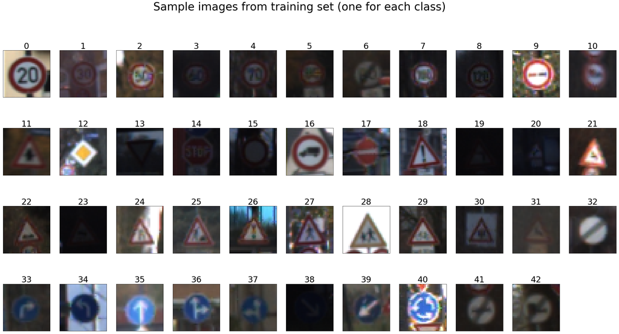

```python
### Data exploration visualization code goes here.
### Feel free to use as many code cells as needed.
import matplotlib.pyplot as plt
# Visualizations will be shown in the notebook.
%matplotlib inline

# Select an example picture from each classes
example_pictures = []
for i in range(n_classes):
    indices= np.where(y_train == i)[0]  # return *n array
    example_pictures.append(X_train[indices[0]])

figure = plt.figure(figsize = (40,20))
plt.suptitle('Sample images from training set (one for each class)', size = 40)
for i in range(n_classes):
    ax = figure.add_subplot(4,11,i+1)
    ax.imshow(example_pictures[i])
    ax.xaxis.set_visible(False)
    ax.yaxis.set_visible(False)
    ax.set_title('{:d}'.format(i), size =30)
```

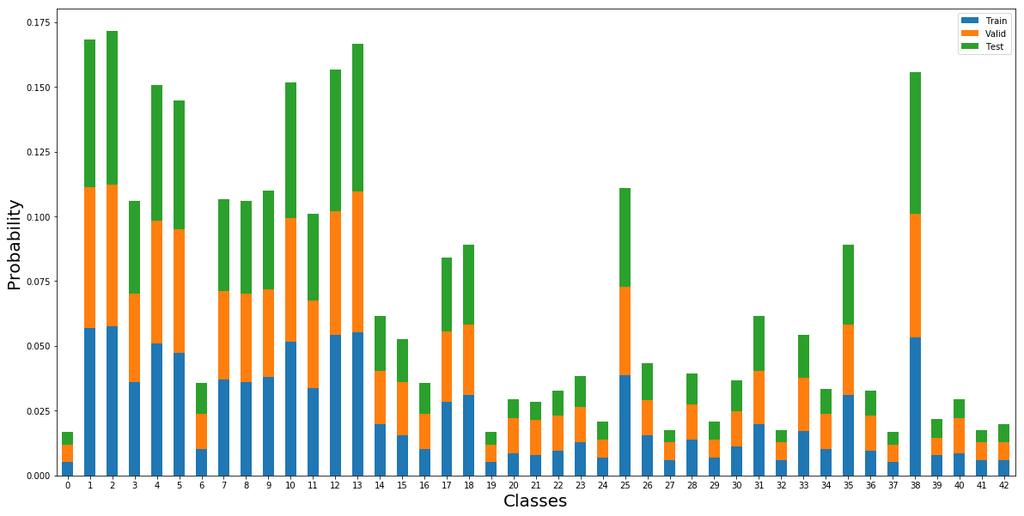

```python
# Visualize the distribution of classes in the training, validation and test set.
Distribution = pd.DataFrame(data = np.zeros((n_classes,3)), columns=['Train', 'Valid','Test'])
for i in range(n_classes):
    Distribution.loc[i, 'Train'] = len(np.where(y_train == i)[0])/n_train
    Distribution.loc[i, 'Valid'] = len(np.where(y_valid == i)[0])/n_validation
    Distribution.loc[i, 'Test'] = len(np.where(y_test == i)[0])/n_test
Distribution.plot.bar(stacked=True,rot=0, figsize=(20,10))
plt.xlabel('Classes',size = 20)
plt.ylabel('Probability', size = 20)
```

## Design and Test a Model Architecture

### (I) Preprocessing

> - The images are first converted into greyscale to speed up the calculation (the amount of data has been reduced into 1/3, a single channel from RGB channels).
> - Then normalized so that the data has mean zero and equal variance. The normalization aids the convergence of gradient descent.

```python
import cv2

def normalization(grey_image):
    # image: 32*32 grey_image
    norm_image = (grey_image - np.mean(grey_image))/np.std(grey_image)
    return norm_image


def preprocess_images(rgb_image):
    """
    image: (32, 32, 3) rgb image
    """
    # Convert from RGB to grayscale
    # 32*32*1 image; add [:,:,None] to extend the dimension; otherwise just 32*32
    grey_image = cv2.cvtColor(rgb_image, cv2.COLOR_RGB2GRAY)[:,:,None]

    # Normalize the image
    # 32*32*1 image
    norm_grey_image = normalization(grey_image)

    return norm_grey_image
```

```python
import random
index = random.randint(0,n_train)
plt.figure(figsize=(1,1))
plt.imshow(X_train[index])
```

[output not shown]

```python
Example_X_train_grey_norm = np.array(preprocess_images(X_train[index]),dtype=np.float32).squeeze()
plt.figure(figsize=(1,1))
plt.imshow(Example_X_train_grey_norm, cmap='gray')
```

[output not shown]

### (II) Model Architecture

My final Convolutional Neural Network Model consisted of the following layers:

[output not shown]

### (III) Model Training

> - Optimizer: Adam Optimizer
> - Batch size: 128
> - Epoch number: 30
> - Learning rate: 0.001
> - Drop out keep probability: 0.75

### (IV) Solution approach

> - Based on the benchmark LetNet Architecture, I made a few changes including adding dropouts to prevent overfitting, and change the final output size.
> - Validation set accuracy: 0.957

## Test the model on new images

### (I) Acquiring new images: five new images are obtained online:

[figure not shown]

```python
import matplotlib.image as mpimg
import cv2
import os,fnmatch

# Placeholders for the images and labels I found from web
web_images = []
resize_web_images = []
web_labels = []

# Image directory
directory = './images'

# Because there is a default ".ipynb_checkpoints" file in the folder, have to eliminate it before it
# causes import problems
jpg_files = fnmatch.filter(os.listdir(directory), '*.jpg')

# Go through all the files
for file in jpg_files:
    image = mpimg.imread(os.path.join(directory, file))
    # Compress the image to 32 by 32
    resize_image =  cv2.resize(image, (32, 32))

    # Add the image to the list
    web_images.append(image)
    resize_web_images.append(resize_image)

    # Get the label number from the file name
    label = np.int8(os.path.splitext(file)[0])
    web_labels.append(label)
# Convert list to arrays
web_images = np.array(web_images)
resize_web_images = np.array(resize_web_images)
web_labels = np.array(web_labels)

reference_labels = np.genfromtxt('signnames.csv', delimiter=',' ,
                            usecols=(1,), unpack=True,
                            dtype=str,  skip_header=1)
figure = plt.figure(figsize = (20,10))
for i in range(len(web_images)):
    ax = figure.add_subplot(2,3,i+1)
    ax.imshow(web_images[i])
    ax.xaxis.set_visible(False)
    ax.yaxis.set_visible(False)
    ax.set_title("Image"+str(i)+": Class {} ({})".format(web_labels[i],reference_labels[web_labels[i]]), size=10)
plt.show()
```

### (II) Performance on the new images

> Predictive accuracy on the web image: 0.8, which is lower than the accuracy result of the test set: 0.932.
> - Apparently the background and resolution of the traffic sign picture plays an important role, because we have to crop/resize the pictures into 32x32x3.

| No. | Image | Prediction |
| --- | --- | --- |
| 0 | Turn right ahead | Turn right ahead |
| 1 | Speed limit (60km/h) | Speed limit (60km/h) |
| 2 | Slippery road | Slippery road |
| 3 | Stop | Stop |
| 4 | Roundabout mandatory | Priority road |

### (III) Model Certainty - Softmax Probabilities

#### For Image 0, the model is relatively sure that this is a right turn sign (probability of 0.45), and the image does contain a right turn sign. The top five soft max probabilities were

| Probability | Prediction class/meaning |
| --- | --- |
| .45 | 33 (Turn right ahead) |
| .28 | 3 (Speed limit (60km/h)) |
| .17 | 11 (Right-of-way at the next intersection) |
| .06 | 40(Roundabout mandatory) |
| .01 | 06 (End of speed limit (80km/h) |

#### For Image 1, the model is certan that this is a Speed limit (60km/h) sign (probability of 1.0), and the image does contain a speed limit (60km/h). The top five soft max probabilities were

| Probability | Prediction class/meaning |
| --- | --- |
| 1.0 | 3 (Speed limit (60km/h)) |
| .0 | 25 (Road work) |
| .0 | 28 (Children crossing) |
| .0 | 02 (Speed limit (50km/h)) |
| .0 | 05 (Speed limit (80km/h)) |

#### For Image 2, the model is quite sure that this is a slippery road sign (probability of 0.98), and the image does contain a slippery road sign. The top five soft max probabilities were

| Probability | Prediction class/meaning |
| --- | --- |
| .98 | 23 (Slippery road) |
| .01 | 20 (Dangerous curve to the right) |
| .0 | 30 (Beware of ice/snow) |
| .0 | 24(Road narrows on the right) |
| .0 | 11 (Right-of-way at the next intersection) |

#### For Image 3, the model is certain that this is a stop sign (probability of 1.0), and the image does contain a stop sign. The top five soft max probabilities were

| Probability | Prediction class/meaning |
| --- | --- |
| 1.0 | 14 (Stop) |
| .0 | 17 (No entry) |
| .0 | 34 (Turn left ahead) |
| .0 | 35(Ahead only) |
| .0 | 38 (Keep right) |

#### For Image 4, the model is not sure whether this is a priority road sign (probability of 0.51) or a roundabout mandatory sign (probability of 0.49), and the image does contain a roundabout mandatory sign. The top five soft max probabilities were

| Probability | Prediction class/meaning |
| --- | --- |
| .51 | 12(Priority road) |
| .49 | 40 (Roundabout mandatory) |
| .0 | 09 (No passing) |
| .0 | 11(Right-of-way at the next intersection) |
| .0 | 13 (Yield) |